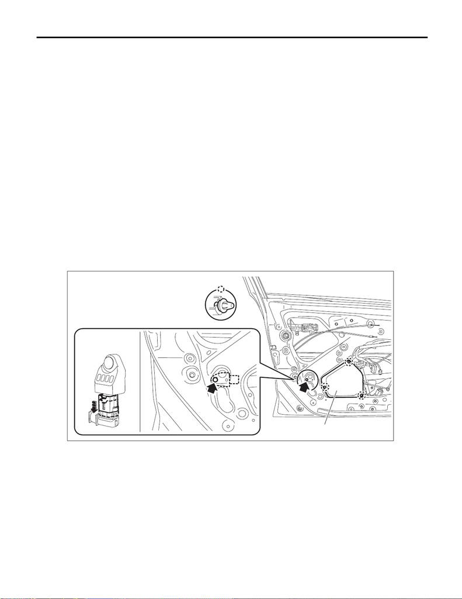

AB-52

Front Door Impact Sensor

AIRBAG SYSTEM

11.Front Door Impact Sensor

A: REMOVAL

CAUTION:

The airbag system is fitted with a backup power supply. After disconnecting the battery ground ca-

ble, the airbag may operate if you do not wait for 60 seconds before starting the service of airbag sys-

tem.

1) Operate the power window switch to close the front door glass.

2) Turn the ignition switch to OFF.

3) Disconnect the ground cable from battery and wait for at least 60 seconds before starting work. <Ref. to

NT-5, BATTERY, NOTE, Note.>

NOTE:

For models other than STI model, disconnect the ground terminal from battery sensor.

4) Remove the trim panel - front door. <Ref. to EI-56, FRONT DOOR, REMOVAL, Door Trim.>

5) Remove the sealing cover. <Ref. to EB-32, REMOVAL, Front Sealing Cover.>

6) Remove the front door impact sensor.

(1) Remove the front door inner pad (a).

CAUTION:

If the clip is damaged, replace it with a new part because the panel assembly - front door may be de-

formed.

(2) Remove the nuts and then remove the front door impact sensor.

(3) Disconnect the airbag connector and remove the front door impact sensor. <Ref. to AB-21, FRONT

DOOR IMPACT SENSOR AND SATELLITE SAFING SENSOR, PROCEDURE, Airbag Connector.>

AB-02911

(a)

[figure not shown]

AB-53

Front Door Impact Sensor

AIRBAG SYSTEM

B: INSTALLATION

1) Before installation, inspect the following items and replace any faulty part with a new part.

• The front door impact sensor or connector is damaged.

• Inner panel area of the panel assembly - front door is deformed.

• Side airbag module has been activated.

2) Install the airbag door sensor.

CAUTION:

Do not reuse the bolt and nut.

Always replace with the specified new bolts and nuts.

Tightening torque:

7.5 N·m (0.8 kgf-m, 5.5 ft-lb)

3) Install the sealing cover.

4) Install the trim panel - front door.

5) Connect the battery ground terminal. <Ref. to NT-5, BATTERY, NOTE, Note.>

NOTE:

For models other than STI model, connect the ground terminal to battery sensor.